# Decision Trees, Random Forest, and Neural Network Models

Reed Frellick, Neil Pierre-Louis, Jimmy Slaight, and Lewis Dubrowski

4/10/2022

```r
library(tree)
library(readr)
library(dplyr)
library(randomForest)
library(caret)
library(pROC)

nhl_data <- read_csv("C:/Users/ljdub/Downloads/all_teams_cleaned.csv",
                     show_col_types = FALSE)
```

Set up the data by choosing the variables we want and splitting into train/test sets

```r
nhl_data$isWin <- factor(nhl_data$isWin)

nhl_data <- nhl_data %>% select(-contains('x'), -goalsFor, -reboundGoalsFor, -lowDangerGoalsFor, -mediumDangerGoalsFor, -highDangerGoalsFor, -goalsAgainst, -reboundGoalsAgainst, -lowDangerGoalsAgainst, -mediumDangerGoalsAgainst, -highDangerGoalsAgainst, -team, -season, -opposingTeam, -iceTime, -contains("Adjusted"), -contains("Danger"), -contains("Credit"), -contains("Percentage"), -missedShotsFor , -shotAttemptsFor , -reboundsFor , -freezeFor , -playStoppedFor , -playContinuedInZoneFor , -savedShotsOnGoalFor , -savedUnblockedShotAttemptsFor , -penaltiesFor , -unblockedShotAttemptsFor , -shotsOnGoalAgainst , -missedShotsAgainst , -blockedShotAttemptsAgainst , -shotAttemptsAgainst , -reboundsAgainst , -playContinuedOutsideZoneAgainst , -savedShotsOnGoalAgainst)

set.seed(100)
sample <- sample.int(n = nrow(nhl_data), size = floor(.80*nrow(nhl_data)), replace = F)


training_set <- nhl_data[sample,]
test_set <- nhl_data[-sample,]
```

Make a basic decision tree

```r
first_tree <- tree(isWin ~ ., data = training_set)
summary(first_tree)
```

```
##
## Classification tree:
## tree(formula = isWin ~ ., data = training_set)
## Variables actually used in tree construction:
## [1] "blockedShotAttemptsFor"
## Number of terminal nodes:  2
## Residual mean deviance:  1.347 = 15160 / 11250
## Misclassification error rate: 0.4052 = 4560 / 11255
```

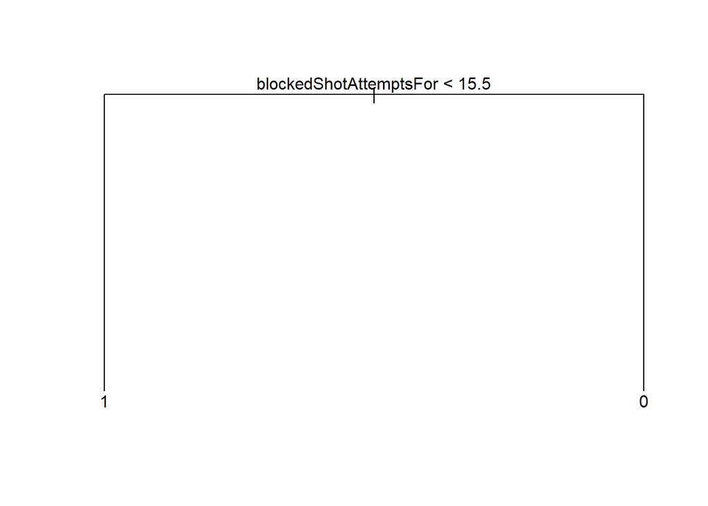

```r
plot(first_tree)
text(first_tree, pretty = 0)
```

This tree only uses one variable, blockedShotAttemptsFor. We can see how successfully it performs on the test data by calculating predictions:

```r
tree.preds <- predict(first_tree, test_set, type = 'class')
confusionMatrix(data = as.factor(tree.preds),
                reference = as.factor(test_set$isWin),
                positive = levels(as.factor(test_set$isWin))[2])
```

```
## Confusion Matrix and Statistics
##
##           Reference
## Prediction    0    1
##          0  608  477
##          1  658 1071
##
##                Accuracy : 0.5967
##                  95% CI : (0.5783, 0.6149)
##     No Information Rate : 0.5501
##     P-Value [Acc > NIR] : 3.461e-07
##
##                   Kappa : 0.1744
##
##  Mcnemar's Test P-Value : 9.149e-08
##
##             Sensitivity : 0.6919
##             Specificity : 0.4803
##          Pos Pred Value : 0.6194
##          Neg Pred Value : 0.5604
##              Prevalence : 0.5501
##          Detection Rate : 0.3806
##    Detection Prevalence : 0.6144
##       Balanced Accuracy : 0.5861
##
##        'Positive' Class : 1
##
```

Considering we are only using one variable, the accuracy is pretty high – almost 60%! This appears to be driven mainly by having good sensitivity, the specificity is below 50%.

Construct an ROC curve and calculate AUC

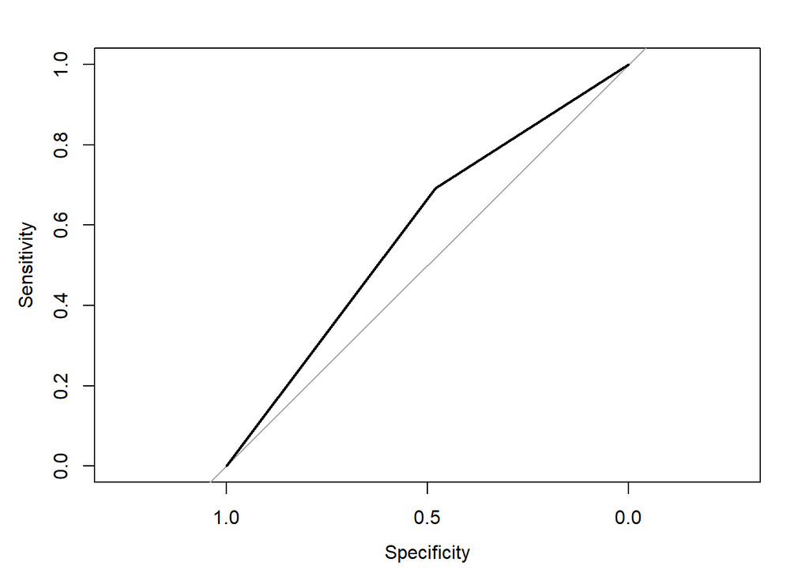

```r
dtree.roc <- roc((test_set$isWin == '1') * 1, (tree.preds == '1') * 1, plot = TRUE)
```

```r
auc(dtree.roc)
```

```
## Area under the curve: 0.5861
```

The AUC is about .59, which is okay. We can probably improve on it though with a random forest model.

Find out the best value for mtry using cross validation and construct a model using that best value.

```r
set.seed(99)
training_set <- as.data.frame(training_set)

tune.rf.nhl <- tuneRF(x = training_set[,-22], y = training_set[,22], mtryStart = 5,
                      ntreeTry = 500)
```

```
## mtry = 5  OOB error = 27.09%
## Searching left ...
## mtry = 3     OOB error = 28.86%
## -0.0652673 0.05
## Searching right ...
## mtry = 10    OOB error = 23.88%
## 0.1183995 0.05
## mtry = 20    OOB error = 20.68%
## 0.1343006 0.05
## mtry = 21    OOB error = 20.96%
## -0.01375161 0.05
```

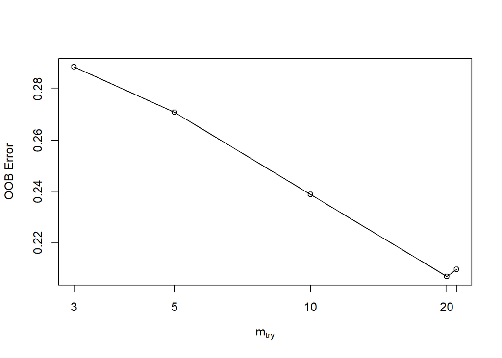

```r
rf.nhl21 <- randomForest(isWin ~., data = training_set, importance = TRUE, mtry = 20)
```

Create predictions based on the model

```r
rf.preds <- predict(rf.nhl21, test_set, type = 'class')
confusionMatrix(data = as.factor(rf.preds),
                reference = as.factor(test_set$isWin),
                positive = levels(as.factor(test_set$isWin))[2])
```

```
## Confusion Matrix and Statistics
##
##           Reference
## Prediction    0    1
##          0  966  248
##          1  300 1300
##
##                Accuracy : 0.8053
##                  95% CI : (0.7901, 0.8197)
##     No Information Rate : 0.5501
##     P-Value [Acc > NIR] : < 2e-16
##
##                   Kappa : 0.6051
##
##  Mcnemar's Test P-Value : 0.02936
##
##             Sensitivity : 0.8398
##             Specificity : 0.7630
##          Pos Pred Value : 0.8125
##          Neg Pred Value : 0.7957
##              Prevalence : 0.5501
##          Detection Rate : 0.4620
##    Detection Prevalence : 0.5686
##       Balanced Accuracy : 0.8014
##
##        'Positive' Class : 1
##
```

Using random forest, the accuracy is much better – about 81%. The sensitivity and specificity are both high.

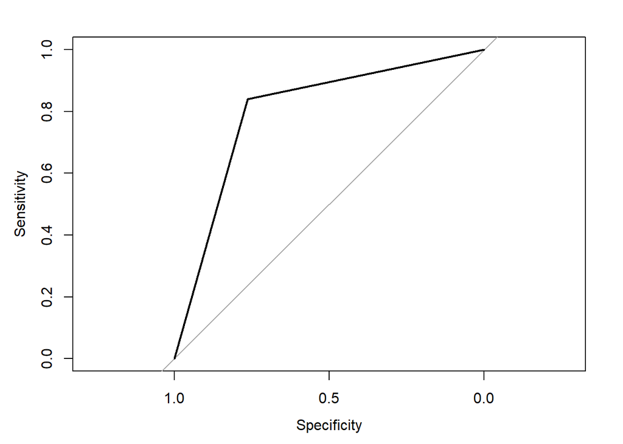

```r
rf.roc <- roc((test_set$isWin == '1') * 1, (rf.preds == '1') * 1, plot = TRUE)
```

```r
auc(rf.roc)
```

```
## Area under the curve: 0.8014
```

The AUC is also around 0.8, which is very strong. It seems like the random forest model does a good job predicting games.

We can see which variables are most important to the random forest model using a variable importance plot:

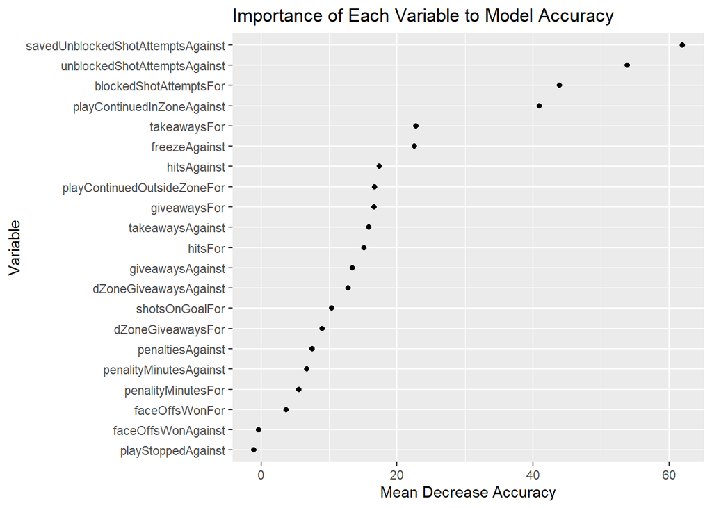

```r
vPlot <- as.data.frame(vPlot) %>% arrange(desc(MeanDecreaseAccuracy))
ggplot(vPlot, aes(x = reorder(rownames(vPlot), MeanDecreaseAccuracy), y = MeanDecreaseAccuracy)) +
  geom_point() +
  xlab("Variable") +
  ylab("Mean Decrease Accuracy") +
  ggtitle("Importance of Each Variable to Model Accuracy") +
  coord_flip()
```

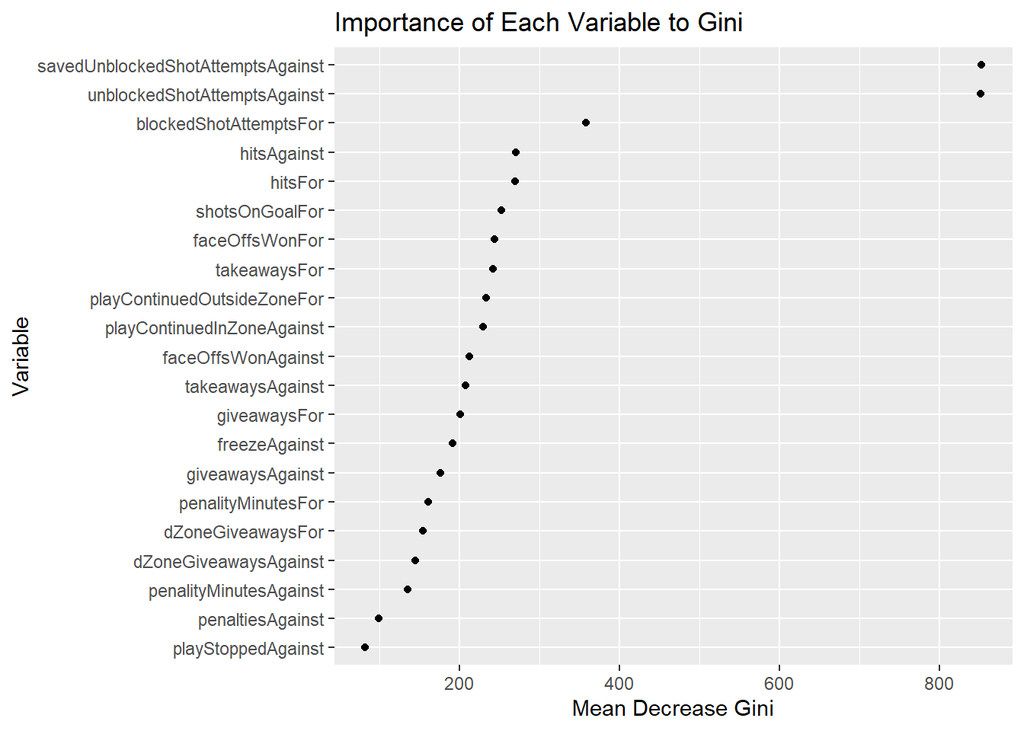

```r
vPlot <- as.data.frame(vPlot) %>% arrange(desc(MeanDecreaseGini))
ggplot(vPlot, aes(x = reorder(rownames(vPlot), MeanDecreaseGini), y = MeanDecreaseGini)) +
  geom_point() +
  xlab("Variable") +
  ylab("Mean Decrease Gini") +
  ggtitle("Importance of Each Variable to Gini") +
  coord_flip()
```

Finally, we can try a neural network model to see if that increases the accuracy further:

```r
library(reticulate)
use_condaenv('tf')
library(tensorflow)
library('keras')

set.seed(156)

x.train <- scale(model.matrix(isWin ~. -1, data = training_set))
y.train <- (training_set$isWin == '1')*1

x.test <- scale(model.matrix(isWin ~. -1, data = test_set))
y.test <- (test_set$isWin == '1')*1

nn.model <- keras_model_sequential() %>%
  layer_dense(units = 15, activation = "softmax",
              input_shape = ncol(x.train)) %>%
  layer_dropout(0.4) %>%
  layer_dense(2, activation = "softmax")

nn.model %>%
  compile(
    loss = 'sparse_categorical_crossentropy',
    optimizer = 'adam',
    metrics = 'accuracy'
  )

nn.model %>%
  fit(
    x = x.train, y = y.train,
    epochs = 10,
    validation_split = 0.3,
    verbose = 2)

predictions <- predict(nn.model, x.test)
head(predictions, 2)
```

```
##           [,1]      [,2]
## [1,] 0.2497087 0.7502914
## [2,] 0.6071101 0.3928899
```

```r
nn.model %>%
  evaluate(x.test, y.test, verbose = 0)
```

```
##      loss  accuracy
## 0.5841441 0.7125089
```

The accuracy for the neural network model is a little better than 70%, much worse than the random forest model.